# hw2-visual

Yiyi

2024-02-27

# My data

```r
library(readxl)
hw1_data <- read_excel("D:/Multivariate_analysis/hw1-data.xlsx")
View(hw1_data)
data<-data.frame(hw1_data)
library(ggplot2)
library(GGally)
```

# Visualization

How is the GPA distributed in all the samples?

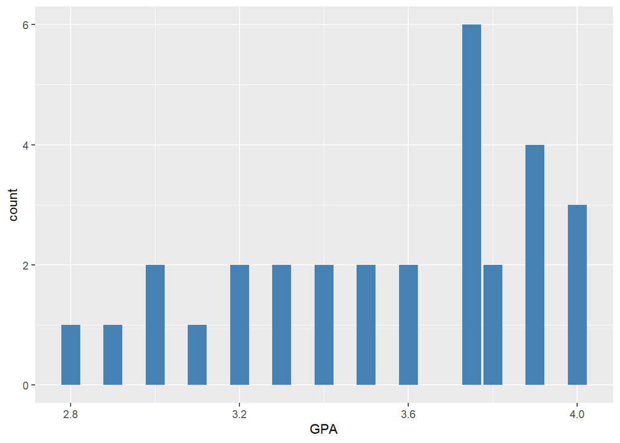

```r
ggplot(data, aes(x=GPA)) + geom_bar(fill="steelblue")
```

The numerical distribution of GPA ranged from approximately 2.8 to 4.0, with GPA values having a maximum distribution between 3.7 and 3.8

How is mental scores of gaming hours distributed in all the samples?

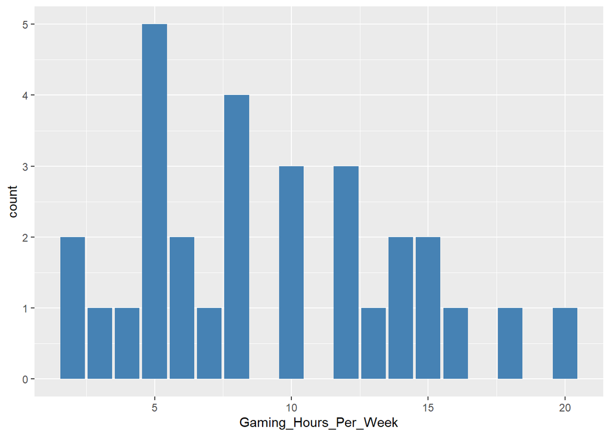

```r
ggplot(data, aes(x=Gaming_Hours_Per_Week)) + geom_bar(fill="steelblue")
```

In the sample, the most students played in 5 and 8 hours per week, with 5 and 4 students, respectively. Only one student plays the most games for 20 hours a week. Only 2 students play only 2 hours a week.

Is there a relationship between GPA and the level of English?

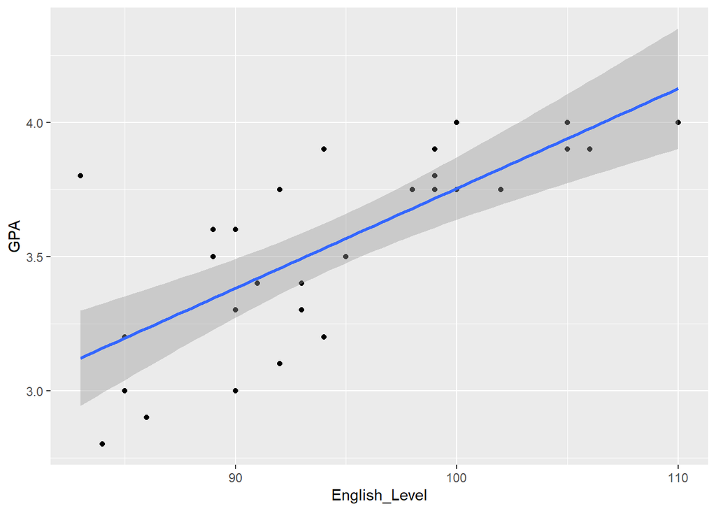

```r
ggplot(data, aes(x=English_Level, y=GPA)) + geom_point() + geom_smooth(method=lm)
```

GPA values are concentrated between 3.00 and 4.00, while TOEFL scores are relatively more dispersed. Students with higher English level tend to have higher GPA,especially at the higher range of TOEFL scores.

Is there a relationship between GPA and the Study hours per week?

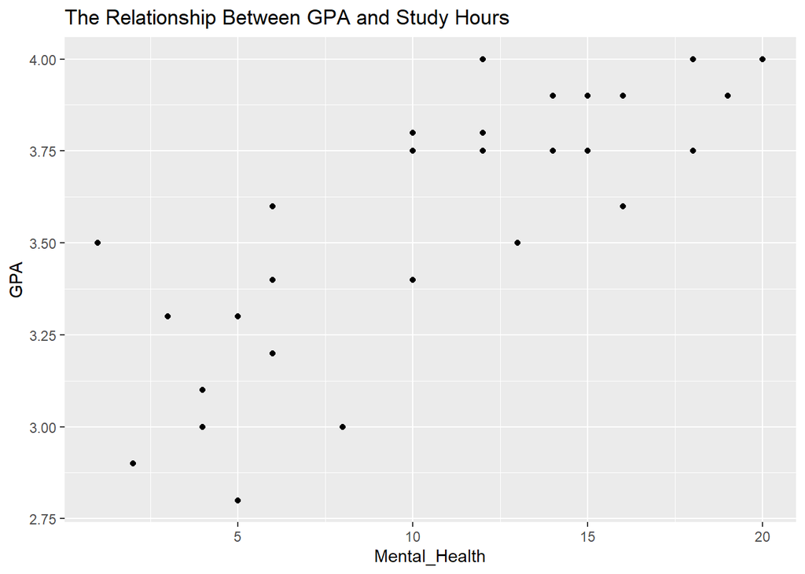

```r
library(ggplot2)
ggplot(data, aes(x=Study_Hours_Per_Week,y=GPA)) +
  geom_point() +
  labs(title="The Relationship Between GPA and Study Hours", x="Mental_Health", y="GPA")
```

Is there a relationship between GPA and the sport time?

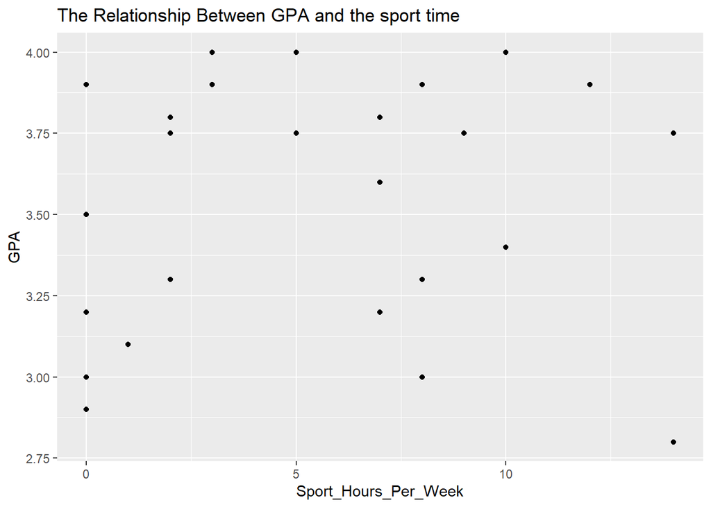

```r
library(ggplot2)
ggplot(data, aes(x=Sport_Hours_Per_Week,y=GPA)) +
  geom_point() +
  labs(title="The Relationship Between GPA and the sport time", x="Sport_Hours_Per_Week", y="GPA")
```

There is no significant correlation between GPA and the sport time.